# Path

# Path and PathFollow constrain the movement of child nodes

`Path` lets you design a smooth curve with [Bezier interpolation](https://en.wikipedia.org/wiki/B%C3%A9zier_curve) in 3D space. The `PathFollow` node moves along a parent `Path` and makes its children follow the path.

You can either draw the path in the viewport or generate curves at runtime. In turn, the two nodes are great for path-following mechanics.

For example, using `Path` and `PathFollow`, you could use the `AStar` pathfinding algorithm to construct paths for units to follow at runtime in a grid-based game.

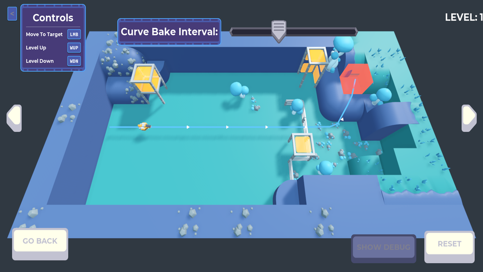

The `Path` node can work on its own without the `PathFollow` child. We’ll cover this when generating a laser beam that shoots from off-screen to a target.

On the other hand, `PathFollow` only works as a child of `Path`, where it gets constrained on the parent’s curve.

In this guide, you’ll learn to:

- Set up the `Path` and `PathFollow` combo for making nodes follow a designated path.
- Make a player unit move along a path generated using an `AStar` algorithm in real-time.
- Generate a random path for a card game for an effective animation.
- Move a platform on a predefined path in a side-scroll demo.
- Create a sweeping laser animation coming from outside the screen.
- Use the `Path` and `PathFollow` in a non-standard way to create a directed force field that influences `RigidBody` nodes.
- Grind rails with obstacles randomly placed along the path.

Contents:

- Setting up a Path and PathFollow to move along the path
- Path’s key features
  - The Curve3D resource
- PathFollow’s key features
  - Offset-based position and rotation
  - Smooth paths with cubic interpolation
  - Optional rotation along the curve
  - Horizontal and vertical offsets
  - Looping and cyclic curves
- How to use Path and PathFollow in practice
  - Real-time paths with the AStar algorithm
  - Random paths for card games
  - Side-scroller platforms following a complex path
  - Paths as force fields
  - Laser swiping effect
  - Rail grinding

## Setting up a Path and PathFollow to move along the path

While you can use the `Path` node on its own to generate Bezier curves, the most common way to use it is to sample positions along the path.

To follow a `Path` node’s curve, you must add a `PathFollow` node as a child of it, like so:

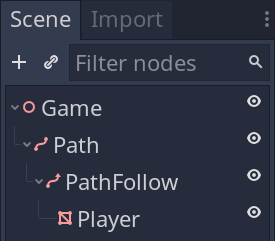

You need to add a new `Curve3D` to the `Path`’s *Curve* property to draw a path.

You can then draw the path in the 3D viewport using the toolbar that appears at the top:

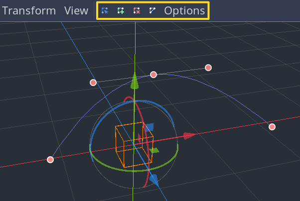

Then you can manipulate the location of `PathFollow` along the curve using either its *Offset* or *Unit Offset* in the *Inspector*:

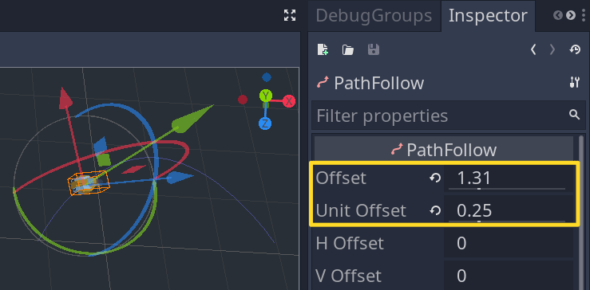

Updating either property automatically updates the other.

## Path’s key features

The purpose of the `Path` node is to hold the `Curve3D` resource. This is its key property.

### The Curve3D resource

You can either draw the curve in the 3D viewport in the editor or manipulate it in code. Both ways are helpful depending on the case.

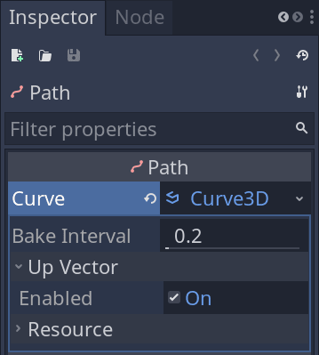

The node precalculates points along the curve using the *Bake Interval* property to save on performance. This value represents the distance in 3D units between two of those points.

By default, the `Curve3D` resource uses a *Bake Interval* of `0.2`, meaning it’ll precalculate one point every `0.2` units.

As we’ll see, this property, combined with `PathFollow`’s *Cubic Interp* property, can generate smooth paths, even if we have a `Curve` with sharp corners.

Here’s a preview with *Bake Interval* set to `2` and *Cubic Interp* both on and off:

[figure not shown]

[figure not shown]

**Note:** If the *Bake Interval* is too large, the arcs followed by `PathFollow` can end up very different from the smooth curve you drew.

`Curve3D` has one more property, *Up Vector -> Enabled*:

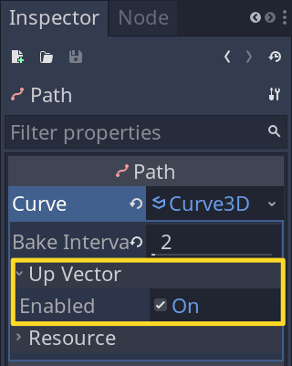

When turned on, Godot precalculates up vectors (the local Y direction) on top of precalculating points along the path. At the time of writing, the tilt of up vectors is challenging to manipulate.

The *Up Vector -> Enabled* property only has effect when setting the `PathFollow` node’s *Rotation Mode* to *Oriented*. This setting causes the node following the path to orient towards the local up vector.

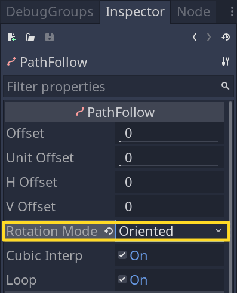

**Note:** At this time, *Orient* is the only mode that works alongside *None*. The other modes don’t work in Godot 3.3 but this is a known problem, and the Godot developers are working on solutions.

## PathFollow’s key features

`PathFollow` only works as a child of a `Path` node. Its key features are that it moves and rotates along its parent path.

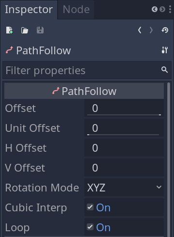

### Offset-based position and rotation

You control the node’s position along the parent path using either the *Offset* or the *Unit Offset* property.

Changing either property causes the other to update as well. The main difference is that the *Offset* is in units while the *Unit Offset* is in the `[0, 1]` range.

A *Unit Offset* of `0` corresponds to the start of the path and `1` corresponds to the end. This makes *Unit Offset* especially useful for interpolating from the start to the end in a set time without having to calculate the step size yourself.

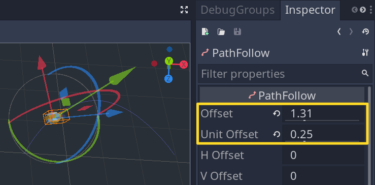

### Smooth paths with cubic interpolation

As we saw, the actual path `PathFollow` takes depends on the `Curve3D`’s *Bake Interval* property. The larger the *Bake Interval*, the more jagged and imprecise the path becomes.

When you turn on *Cubic Interp* on the `PathFollow`, it smoothly interpolates between the cached curve points, even if the curve has sharp corners.

[figure not shown]

### Optional rotation along the curve

The other notable feature of `PathFollow` is the *Rotation Mode* property. If we set it to *Oriented*, the node aligns its rotation to match the curve direction.

This works by aligning the local Z-axis along the path’s tangent and the Y-axis along the up vector. For this to work, we have to turn on *Up Vector -> Enabled* on `Curve3D`.

To turn off this behavior, we can choose *None* for *Rotation Mode*.

As mentioned before, at the time of writing, the other rotation options have unexpected behavior.

### Horizontal and vertical offsets

As the name implies, *H Offset* and *V Offset* add horizontal and vertical offsets to the position of the `PathFollow` node.

For example, by duplicating a `PathFollow` twice:

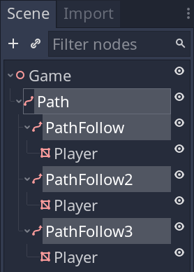

And setting different *H Offset* and *V Offset* on each, we can get a uniform mob movement pattern:

[figure not shown]

Although this setup looks very mechanical, adding some randomness to the *H Offset* and *V Offset* properties can give interesting results.

### Looping and cyclic curves

Finally, the *Loop* property forces any *Offset* value outside the `Curve3D` length to wrap around. This is useful for cyclic paths. We create a cyclic path by having the first and last points coincide.

There’s no need to place the last point of the curve manually. We can generate a final point that aligns perfectly with the first using the *Close Curve* button from the toolbar:

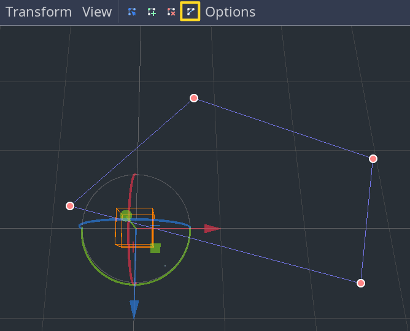

## How to use Path and PathFollow in practice

This section looks at standard examples of using the `Path` and `PathFollow` combo and more creative cases.

### Real-time paths with the AStar algorithm

In this example, we have a game that uses a `GridMap` and the `AStar` algorithm to construct a path for the player ship to follow.

We use the `Path` and `PathFollow` combo to create real-time paths on player mouse click. The path starts at the current ship position and ends at the center of the clicked tile.

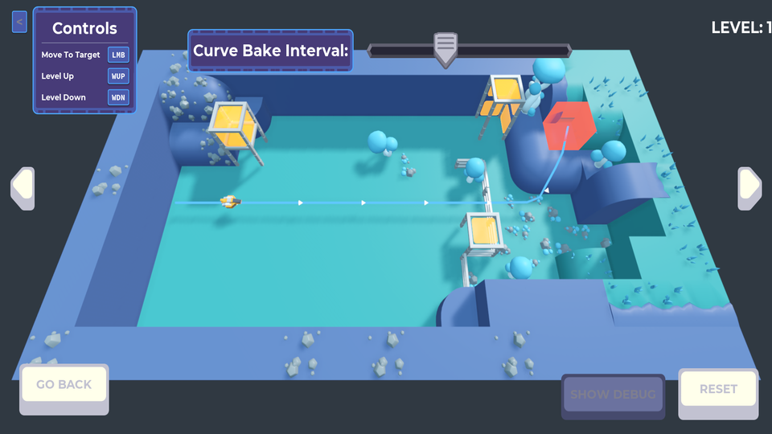

To find and follow paths, we use the following nodes:

- A `GridMap` serves as the game’s grid. We treat occupied cells as obstacles.
- A `Path` with a child `PathFollow` to generate a curve and follow it.
  - We add a character as a child of the `PathFollow`, a `MeshInstance`, that’ll automatically move along with its parent.

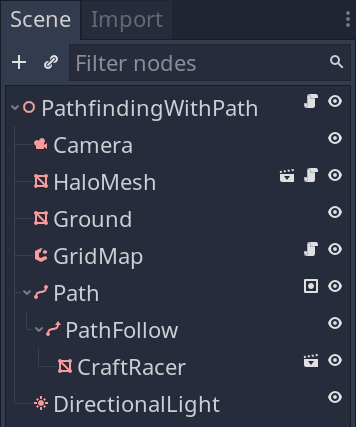

The additional nodes are:

- A `Camera` node is required for 3D scenes to work and get the mouse interaction with the 3D game world.
- A `MeshInstance` called *HaloMesh* that acts as the mouse pointer to know where we click on.
- A `MeshInstance` called *Ground* which is just a plane that acts as the ground floor.
- A `DirectionalLight` to make the scene more appealing.

We make sure to set *Rotation Mode* to *Oriented* and turn off the `PathFollow`’s *Loop* property. Otherwise, the ship restarts the path movement from the beginning forever.

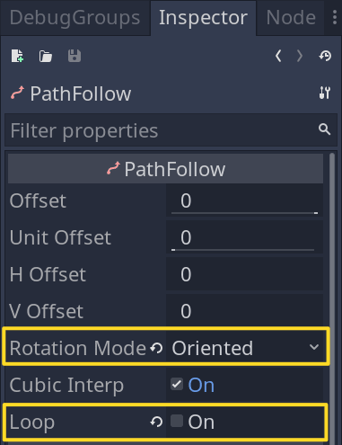

**Note:** *Rotation Mode* forces the Z direction of the child nodes to face the path tangent.

Before coding the pathfinding demo, we take a short detour to add a missing function to `GridMap`.

Unlike the `Tilemap` node, the `GridMap` node doesn’t have a built-in method to get the size of the volume occupied by the used cells. But this is a function we can code ourselves. In a `GridMap.gd` script attached to `GridMap`, we add this code:

```
extends GridMap


func get_used_aabb() -> AABB:
    var cells := get_used_cells()
    cells.sort()

    var first: Vector3 = cells.front()
    var last: Vector3 = cells.back()
    return AABB(first, last - first + Vector3.ONE)
```

The `AABB` object is the 3D equivalent of `Rect2` used in 2D games. It’s an upright box representing an object’s bounds in the game world. In our case, the `AABB` represents the volume in number of used cells.

Getting back on track to coding the pathfinding demo, we start by referencing our necessary nodes from code:

```
# We reference our scene's key nodes and use them for pathfinding.
onready var _camera: Camera = $Camera
onready var _gridmap: GridMap = $GridMap
onready var _halo_mesh: MeshInstance = $HaloMesh
onready var _path: Path = $Path
onready var _path_follow: PathFollow = $Path/PathFollow
```

Moving the `PathFollow` node along the `Path`’s `Curve3D` happens in `_process()`.

By default, we disable `_process()` and only enable it when updating the curve, after a mouse click from the player.

We need a few variables to calculate the player ship speed:

```
## The ship's maximum speed in units per second.
const SPEED_MAX := 16.0

## The ship's current speed in units per second.
var _speed := 0.0
var _acceleration := 6.0
```

As our environment has different heights, we need to keep track of the `GridMap` level the mouse points to on the Y-axis.

```
var _level := 0 setget _set_level

func _set_level(value: int) -> void:
    # We use `posmod()` to make sure that value never exits the `[0,
    # _gridmap_aabb.size.y]` range.
    _level = posmod(value, _gridmap_aabb.size.y)
```

With that out of the way, we move to the `_process()` function:

```
func _process(delta: float) -> void:
    _speed = min(_speed + _acceleration * delta, SPEED_MAX)
    _path_follow.offset += _speed * delta

    if _path_follow.offset >= _path.curve.get_baked_length():
        _speed = 0.0
        set_process(false)
```

To construct the curve based on the `AStar` algorithm and issue the move command, we:

1. Find the path to the grid cell the player clicked.
2. Clear the current *Path Curve* and add the points from the first step to it.
3. Enable `_process()` to start the ship movement.

To get the ship to move along the path, we call two functions: `find_path()` and `move_along()`.

```
func _unhandled_input(event: InputEvent) -> void:
    if event.is_action_pressed("click"):
        move_along(find_path())
    elif event.is_action_pressed("level_up"):
        _set_level(_level + 1)
    elif event.is_action_pressed("level_down"):
        _set_level(_level - 1)

    # On mouse motion we recalculate the `HaloMesh` position based on the mouse
    # pointer.
    if event is InputEventMouseMotion:
        # We convert to map coordinates and reconvert to world coordinates in
        # order to round the `position` to the nearest `GridMap` cell.
        var position := _gridmap.world_to_map(mouse_position_to_xyz(event.position))
        _halo_mesh.translation = _gridmap.map_to_world(position.x, position.y, position.z)
        _halo_mesh.translation += _gridmap_offset

## Returns the location in 3D space based on a ray shooting from the mouse
## position and intersecting a plane that is perpendicular with `Vecctor3.UP`.
## Its depth is given by `_level`.
func mouse_position_to_xyz(mouse_position: Vector2) -> Vector3:
    # We use a small "uncertainty" to the `_level` so we won't worry about
    # rounding errors.
    return Plane(Vector3.UP, _gridmap.cell_size.y * _level + 1e-4).intersects_ray(
        _camera.project_ray_origin(mouse_position),
        _camera.project_ray_normal(mouse_position)
    )
```

The `find_path()` function asks the `AStar` object for a path, an array of grid coordinates to move to the target position.

```
## Gets the `AStar` point-path given by the `PathFollow` current position and
## the input `HaloMesh` position which correspond to the mouse pointer.
func find_path() -> PoolVector3Array:
    var out: PoolVector3Array = []

    # First get the start and finish `AStar` indices based on `PathFollow` and
    # respectively the mouse click locations, through `HaloMesh`.
    var start_index := xyz_to_index(_gridmap.world_to_map(_path_follow.translation))
    var finish_point := _gridmap.world_to_map(_halo_mesh.translation)
    var finish_index := xyz_to_index(finish_point)

    # We also check `_gridmap_aabb.has_point()` because `xyz_to_index` works
    # only for positive positions
    if (_gridmap_aabb.has_point(finish_point)
        and _astar.has_point(start_index)
        and _astar.has_point(finish_index)
    ):
        out = _astar.get_point_path(start_index, finish_index)

    return out
```

We define two utility functions to convert 3D coordinates to unique indices and vice-versa. We need this as the pathfinding algorithm works with indices.

```
# We use the following two functions to convert values between grid coordinates
# and indices.
func xyz_to_index(offset: Vector3) -> int:
    return int(offset.x + _gridmap_aabb.size.x * (offset.y + _gridmap_aabb.size.y * offset.z))


func index_to_xyz(index: int) -> Vector3:
    var x := index % int(_gridmap_aabb.size.x)
    var y := (index / int(_gridmap_aabb.size.x)) % int(_gridmap_aabb.size.y)
    var z := index / int(_gridmap_aabb.size.x * _gridmap_aabb.size.y)
    return Vector3(x, y, z)
```

Last is the `move_along()` function, which takes the path output by `find_path()` and updates the `Path` node’s `curve` for the ship to move to the target.

```
## Generates a new curve based on a path output by the AStar object and turns on
## processing.
func move_along(path: Array) -> void:
    if path.empty():
        return

    _path.curve.clear_points()
    _path.curve.add_point(_path_follow.translation)

    for index in range(1, path.size()):
        var point := _gridmap.map_to_world(path[index].x, path[index].y, path[index].z)
        point += _gridmap_offset
        _path.curve.add_point(point)

    _path_follow.offset = 0.0
    set_process(true)
```

### Random paths for card games

In this demo, we animate cards moving from the player’s hand to the table slots.

To do so, we generate random motion paths.

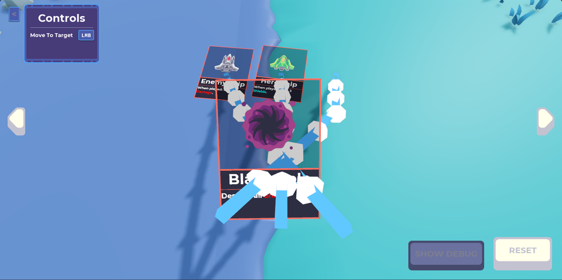

This example uses this scene setup:

- The *Slots* are locations to which the cards can move.
- Each card lives in the *Hand* and is composed of:
  - A `Path` with a child `PathFollow`.
  - As a child of the `PathFollow`, we have the card’s visuals.
  - We use a `Tween` node to animate the `PathFollow`’s offset and move the card along the path.

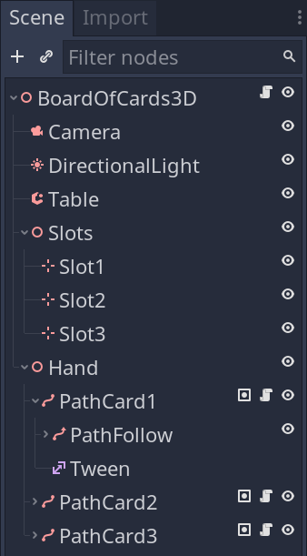

Along with the nodes that contribute specifically to the mechanics, we have a `Camera` since we’re dealing with 3D.

The `DirectionalLight` improves the screen’s looks, and the *Table* node is a `MeshInstance` holding a plane mesh acting as the visual representation of the table.

To learn more about designing a card, check out the PanelContainer guide.

To animate the cards, we calculate a path with three points, where the first and last are:

1. The first point is the card’s position.
2. The last point is the position of the first empty slot from the left.

To add variety to the animation, we construct the curve’s middle point by first calculating the average position between the first and last point.

Then we add a random perturbation on the X-axis.

Given an array of target positions, a `RandomNumberGenerator`, and references to the relevant nodes, we can construct a curve when the player clicks on a card.

We attach the following code to each card.

```
## Stores the position of every slot the card can move to.
## See `setup()` below for its initialization.
var _slot_positions := []
var _rng := RandomNumberGenerator.new()

onready var _path_follow: PathFollow = $PathFollow
onready var _card: MeshInstance = $PathFollow/BoardCard
# Each card has a visual border we use to detect when the player hovers and
# clicks the card. You can do that the Area node.
onready var _card_area: Area = $PathFollow/BoardCard/Area
onready var _tween: Tween = $Tween

func setup(slot_positions: Array) -> void:
    _slot_positions = slot_positions
```

We handle this interaction in the `_on_CardArea_input_event()` function. We first connect to the `Area` node’s signals in `_ready()`:

```
func _ready() -> void:
    _card_area.connect("input_event", self, "_on_CardArea_input_event")
    _card_area.connect("mouse_entered", self, "_on_CardArea_mouse_entered_exited", [true])
    _card_area.connect("mouse_exited", self, "_on_CardArea_mouse_entered_exited", [false])
    _rng.randomize()
```

And for the actual path construction:

```
# The `Area` `input_event` signal emits when the player applies input to the node,
# for example, by clicking on it. It won't trigger if the player clicks elsewhere
# on the screen.
func _on_CardArea_input_event(
        _camera: Node,
        event: InputEvent,
        _click_position: Vector3,
        _click_normal: Vector3,
        _shape_idx: int
    ) -> void:
    if event.is_action_pressed("click"):
        # Get the next slot position, this will also shrink the array.
        var slot_position: Vector3 = _slot_positions.pop_back()

        # Find the mean position between the card and the slot and apply
        # a random offset on the X axis for added variation.
        var offset: Vector3 = (_path_follow.translation + slot_position) / 2.0
        offset.x += _rng.randf_range(-1, 1)

        # Add the points to the curve: the current card position, the middle offset and
        # the final slot position.
        curve.clear_points()
        curve.add_point(_path_follow.translation)
        curve.add_point(offset)
        curve.add_point(slot_position)

        # Here, we animate the card moving along the path.
        _tween.stop_all()
        _tween.interpolate_property(
            _path_follow, "unit_offset", 0, 1, 0.6, Tween.TRANS_QUAD, Tween.EASE_OUT
        )

        # We also animate the rotation with the `Tween` node because we want a specific orientation
        # to match the table. For that reason we have `PathFollow.rotation_mod = ROTATION_NONE`.
        _tween.interpolate_property(
            _path_follow, "rotation:x", _path_follow.rotation.x,
            -PI / 2.0, 0.6, Tween.TRANS_QUAD, Tween.EASE_OUT
        )
        _tween.interpolate_property(
            _path_follow, "rotation:y", _path_follow.rotation.y,
            _rng.randf_range( -PI, PI) / 20.0, 0.6, Tween.TRANS_QUAD, Tween.EASE_OUT
        )

        # We animate the card going up when hovering it with the mouse. So we
        # need to move it back to its original position quickly to avoid having
        # it offset from the card slot.
        _tween.interpolate_property(_card, "translation:y", _card.translation.y, 0, 0.1, Tween.TRANS_CUBIC, Tween.EASE_IN, 0.7)
        _tween.start()

        # Once the player placed a card, they shouldn't be able to click it
        # anymore. That's why we disconnect from the signals.
        _card_area.disconnect("input_event", self, "_on_CardArea_input_event")
        _card_area.disconnect("mouse_entered", self, "_on_CardArea_mouse_entered_exited")
        _card_area.disconnect("mouse_exited", self, "_on_CardArea_mouse_entered_exited")
```

### Side-scroller platforms following a complex path

In this example, we construct a platform following an arbitrary curve instead of the regular horizontal or vertical motions.

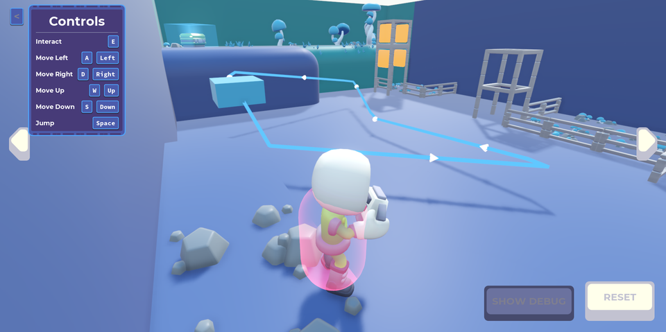

Interestingly enough, this demo doesn’t need any code other than the code for camera and player movement, and perhaps interactables, like the chest.

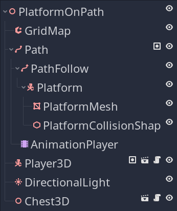

To make the *Platform* do a complete cycle, we animate the `PathFollow`’s `unit_offset` property from `0` to `1`:

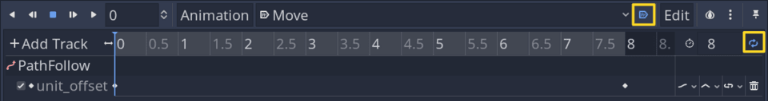

I picked an `8` second long animation for the cycle, made sure to autoplay the *Move* animation, and made it loop.

In this demo, the *Platform* node under `PathFollow` is a `KinematicBody` with a simple cube `MeshInstance` and `CollisionShape`.

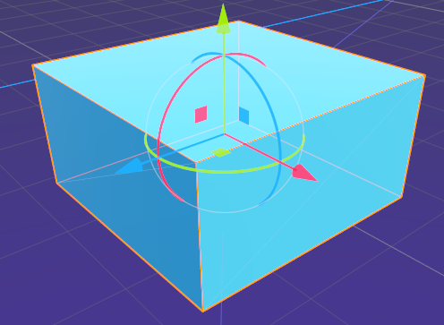

We also need to set the *AnimationPlayer -> Process Mode* to *Physics* to synchronize it with the physics frames. Godot 3.4 is looking to improve the situation there with new code to synchronize `KinematicBody` nodes and animated objects.

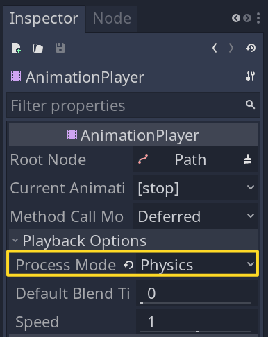

### Paths as force fields

Thinking outside the box, we can use the `Path` and `PathFollow` combo for other purposes, apart from constraining nodes’ movement on curves.

In this demo, we use paths to construct a force field that directs the movement of `RigidBody` nodes:

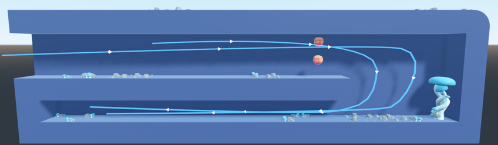

To start us off, we have this scene setup:

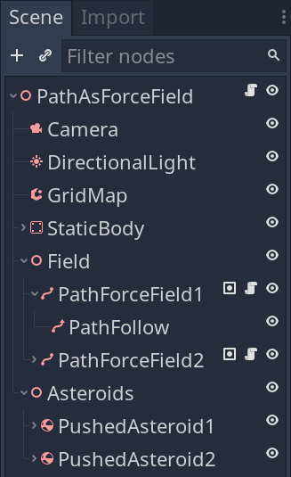

The *Field* node contains two paths we use to apply a force to nearby asteroids. The asteroids live under a separate node, *Asteroids*.

On the `Path` nodes, we defined a few export variables for easy access in the *Inspector*:

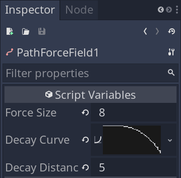

The idea is that the force is strongest if an asteroid is right on the path, with a value of *Force Size*.

It then decays up to *Decay Distance* following the *Decay Curve* profile.

```
export var force_size := 500.0
export var decay_curve: Curve = Curve.new()
export var decay_distance := 500.0
```

On the root node, we have a script for calculating the force based on the paths and applying it to the `RigidBody` nodes under *Asteroids*.

Start by getting references to the appropriate nodes:

```
onready var _field: Spatial = $Field
onready var _asteroids: Spatial = $Asteroids
```

We can calculate the force at a given point anyway we want, based on the path. This is how we do it here:

```
## Calculate a force at the given input position, based on the proximity to the
## available paths.
func calculate_force(input_position: Vector3) -> Vector3:
    var force := Vector3.ZERO

    for path in _field.get_children():
        var path_follow: PathFollow = path.get_node("PathFollow")

        # Move `PathFollow` to the closest point to `input_position`, on the curve.
        path_follow.offset = path.curve.get_closest_offset(input_position)

        # Calculate the force at distance given the decay `Curve`.
        var vector_from_input_position := path_follow.translation - input_position
        var force_size_at_distance = path.force_size * path.decay_curve.interpolate_baked(
            min(vector_from_input_position.length() / path.decay_distance, 1.0)
        )
        force += force_size_at_distance * path_follow.transform.basis.z

    return force
```

We calculate the total force by adding the contribution to all paths under the *Field* node.

Then for every `RigidBody`, in our case called *PushedAsteroid*, we apply the force:

```
func _physics_process(_delta: float) -> void:
    for asteroid in _asteroids.get_children():
        asteroid.add_central_force(calculate_force(asteroid.translation))
```

### Laser swiping effect

We’ll see how to fire a laser from off-screen onto a moving target for this demonstration.

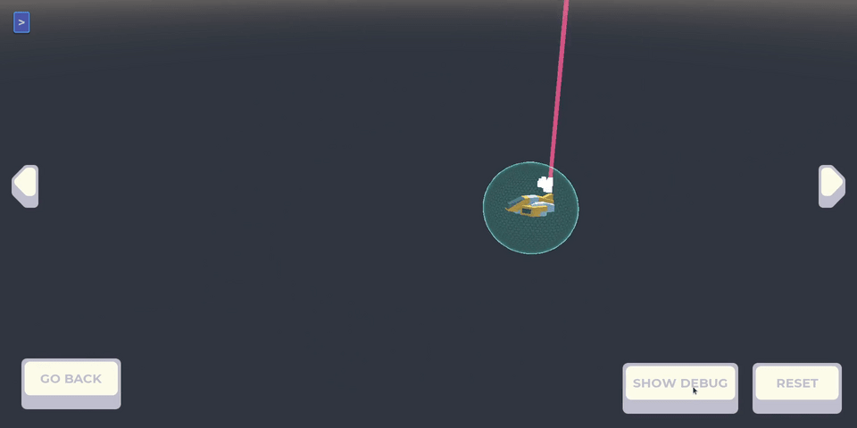

The setup for this scene is as follows:

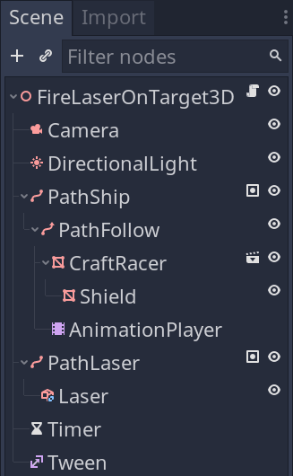

The *CraftRacer* moves in an infinite loop along the *PathShip* curve.

The laser firing mechanism works like this:

1. We pick a random position off-screen on a hemisphere, so the laser always appears to shoot from the top.
2. We pick two random positions on a hemisphere that faces the camera at a radius that matches the *Shield* visual. These positions are relative to *CraftRacer*.
3. We swipe the *PathLaser* using the `Tween` node and the two random positions from the previous point.

We fire the laser every time `Timer` emits the `timeout` signal.

We use a `CSGPolygon` called *Laser* with a translucent material for the laser visual.

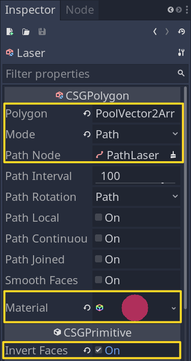

We make sure to turn on *Invert Faces*, otherwise, the laser shape looks wrong.

We start coding by storing the desired laser swipe duration in a constant and a `RandomNumberGenerator` to randomize the laser.

We also store references to all the nodes we need in the script.

```
## The duration of the laser beam's swipe animation in seconds.
const LASER_ANIMATION_DURATION := 0.4

# We use a random number generator to randomize the swipe animation, as well as
# the position of the laser outside the screen.
var _rng := RandomNumberGenerator.new()

onready var _path_follow: PathFollow = $PathShip/PathFollow
onready var _path_laser_curve: Curve3D = $PathLaser.curve
onready var _timer: Timer = $Timer
onready var _tween: Tween = $Tween
```

As I said, we fire the laser every time the `Timer` emits the `timeout` signal.

We also need to reset the *Laser* points at the end of each swipe. So we prepare the connections and defaults in the `_ready()` function and the cleanup in `_on_Tween_tween_all_completed()`:

```
func _ready() -> void:
    _rng.randomize()
    _timer.connect("timeout", self, "_on_Timer_timeout")
    _tween.connect("tween_all_completed", self, "_on_Tween_tween_all_completed")


func _on_Tween_tween_all_completed() -> void:
    _path_laser_curve.clear_points()
```

Next, we have the `_on_Timer_timout()` and the `_animate_laser_swipe()` functions:

```
func _on_Timer_timeout() -> void:
    var offset := _randv_hemisphere(50)
    for _i in range(2):
        _path_laser_curve.add_point(offset)


    _tween.stop_all()
    _tween.interpolate_method(
        self, "_animate_laser_swipe", _randv_hemisphere(1), _randv_hemisphere(1),
        LASER_ANIMATION_DURATION, Tween.TRANS_LINEAR, Tween.EASE_IN
    )
    _tween.start()
    # Seeking forces the tween to update the animation state. Otherwise, the laser's position won't
    # update until the next frame, causing visual artifacts.
    _tween.seek(0.0)

    _timer.wait_time = _rng.randf_range(1, 2)


func _animate_laser_swipe(offset: Vector3) -> void:
    var position := _path_follow.translation + offset
    _path_laser_curve.set_point_position(1, position)
```

We finish with `_randv_hemisphere()` for generating random numbers on a hemisphere of a given radius.

```
func _randv_hemisphere(radius: int) -> Vector3:
    var v := Vector3.RIGHT.rotated(Vector3.DOWN, _rng.randf_range(0.0, PI))
    return radius * v.rotated(v.cross(Vector3.UP), _rng.randf_range(0.0, 0.5 * PI))
```